# BMs353 Bioinformatics for Biomedical Science - Week 2

Module Coordinator Mark Dunning

# Introduction

In this tutorial we will get our first look at how to analyse high-throughput biological data in R. The majority of the course will discuss RNA-seq data for gene expression, but in this session we will consider data from an older technology; *microarrays*.

Although considered outdated by many, the prevalence of microarrays in public repositories make them a valuable resource.

You will need to have installed the following packages before starting:-

```r
install.packages("BiocManager")
BiocManager::install("GEOquery")
BiocManager::install("limma")
```

# Importing the data

The data from this experiment comprises nine paired tumor/normal colon tissues on Illumina HT12_v3 gene expression Beadchips. We will assume that you already know the accession number (GSE….) for the dataset that you want to download.

The function to download a GEO dataset is `getGEO` from the `GEOquery` package. You have to specify the ID of the dataset that you want. To download your own data, replace `GSE33126` with the ID that you’re interested in.

```r
library(GEOquery)
## change my_id to be the dataset that you want.
my_id <- "GSE33126"
gse <- getGEO(my_id)
```

Some datasets on GEO may be derived from different microarray platforms. Therefore the object `gse` is a list of different datasets. You can find out how many were used by checking the length of the `gse` object. Usually there will only be one platform and the dataset we want to analyse will be the first object in the list (`gse[[1]]`).

```r
## check how many platforms used
length(gse)
```

```
## [1] 1
```

```r
gse <- gse[[1]]
gse
```

```
## ExpressionSet (storageMode: lockedEnvironment)
## assayData: 48803 features, 18 samples
##   element names: exprs
## protocolData: none
## phenoData
##   sampleNames: GSM820516 GSM820517 ... GSM820533 (18 total)
##   varLabels: title geo_accession ... tissue:ch1 (34 total)
##   varMetadata: labelDescription
## featureData
##   featureNames: ILMN_1343291 ILMN_1343295 ... ILMN_2416019 (48803
##     total)
##   fvarLabels: ID nuID ... GB_ACC (30 total)
##   fvarMetadata: Column Description labelDescription
## experimentData: use 'experimentData(object)'
##   pubMedIds: 23028787
## Annotation: GPL6947
```

```r
## if more than one dataset is present, you can analyse the other dataset by changing the number inside the [[...]]
## e.g. gse <- gse[[2]]
```

```r
pData(gse) ## print the sample information
fData(gse) ## print the gene annotation
exprs(gse) ## print the expression data
```

# Check the normalisation and scales used

For visualisation and statistical analysis, we will inspect the data to discover what *scale* the data are presented in. The methods we will use assume the data are on a log$_2$ scale; typically in the range of 0 to 16.

The `exprs` function can retrieve the expression values as a data frame; with one column per-sample and one row per-gene.

The `summary` function can then be used to print the distributions.

```r
## exprs get the expression levels as a data frame and get the distribution
summary(exprs(gse))
```

```
##    GSM820516         GSM820517         GSM820518         GSM820519
##  Min.   :  137.4   Min.   :  132.6   Min.   :  132.6   Min.   :  132.6
##  1st Qu.:  212.1   1st Qu.:  212.1   1st Qu.:  212.0   1st Qu.:  212.1
##  Median :  244.9   Median :  245.0   Median :  244.9   Median :  244.9
##  Mean   : 1247.1   Mean   : 1247.1   Mean   : 1247.0   Mean   : 1247.1
##  3rd Qu.:  508.2   3rd Qu.:  508.2   3rd Qu.:  508.0   3rd Qu.:  508.2
##  Max.   :71775.3   Max.   :71775.3   Max.   :71775.3   Max.   :71775.3
##    GSM820520         GSM820521         GSM820522         GSM820523
##  Min.   :  132.6   Min.   :  137.4   Min.   :  132.6   Min.   :  132.6
##  1st Qu.:  212.0   1st Qu.:  212.1   1st Qu.:  212.1   1st Qu.:  212.1
##  Median :  244.9   Median :  244.9   Median :  244.9   Median :  244.9
##  Mean   : 1247.1   Mean   : 1247.1   Mean   : 1247.1   Mean   : 1247.1
##  3rd Qu.:  508.2   3rd Qu.:  508.2   3rd Qu.:  508.2   3rd Qu.:  508.2
##  Max.   :71775.3   Max.   :71775.3   Max.   :71775.3   Max.   :71775.3
##    GSM820524         GSM820525         GSM820526         GSM820527
##  Min.   :  132.6   Min.   :  132.6   Min.   :  132.6   Min.   :  132.6
##  1st Qu.:  212.1   1st Qu.:  212.1   1st Qu.:  212.0   1st Qu.:  212.1
##  Median :  245.0   Median :  245.0   Median :  244.9   Median :  245.0
##  Mean   : 1247.2   Mean   : 1247.2   Mean   : 1247.1   Mean   : 1247.2
##  3rd Qu.:  508.2   3rd Qu.:  508.3   3rd Qu.:  508.3   3rd Qu.:  508.2
##  Max.   :71775.3   Max.   :71775.3   Max.   :71775.3   Max.   :71775.3
##    GSM820528         GSM820529         GSM820530         GSM820531
##  Min.   :  132.6   Min.   :  137.4   Min.   :  132.6   Min.   :  132.6
##  1st Qu.:  212.1   1st Qu.:  212.1   1st Qu.:  212.1   1st Qu.:  212.1
##  Median :  245.0   Median :  245.0   Median :  244.9   Median :  244.9
##  Mean   : 1247.1   Mean   : 1247.1   Mean   : 1247.0   Mean   : 1247.1
##  3rd Qu.:  508.3   3rd Qu.:  508.2   3rd Qu.:  507.7   3rd Qu.:  507.9
##  Max.   :71775.3   Max.   :71775.3   Max.   :71775.3   Max.   :71775.3
##    GSM820532         GSM820533
##  Min.   :  132.6   Min.   :  132.6
##  1st Qu.:  212.1   1st Qu.:  212.1
##  Median :  245.0   Median :  245.0
##  Mean   : 1247.1   Mean   : 1247.1
##  3rd Qu.:  508.1   3rd Qu.:  508.0
##  Max.   :71775.3   Max.   :71775.3
```

From this output we clearly see that the values go beyond 16, so we will need to perform a $log_2$ transformation. A `boxplot` can also be generated to see if the data have been normalised. If so, the distributions of each sample should be highly similar.

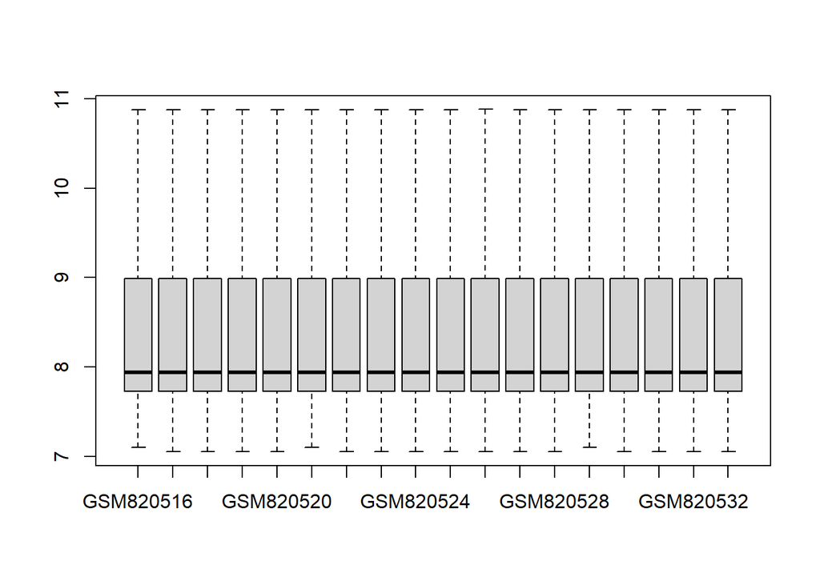

```r
exprs(gse) <- log2(exprs(gse))
boxplot(exprs(gse),outline=FALSE)
```

# Inspect the clinical variables

Data submitted to GEO contain sample labels assigned by the experimenters, and some information about the processing protocol. All these data can be extracted by the `pData` function.

**For your own data, you will have to decide which columns will be useful in the analysis**. This will include the column giving the main comparison(s) of interest and any potential confounding factors. In this particular dataset it looks like `source_name_ch1` and `characteristics_ch1.1`.

We can use the `select` function from `dplyr` to display just these columns of interest. At this stage it will also be useful to rename the columns to something more convenient using the `rename` function.

```r
library(dplyr)
sampleInfo <- pData(gse)
sampleInfo
```

```
##                                title geo_accession                status
## GSM820516  C1 (gene expression data)     GSM820516 Public on Nov 26 2012
## GSM820517  C2 (gene expression data)     GSM820517 Public on Nov 26 2012
## GSM820518  C3 (gene expression data)     GSM820518 Public on Nov 26 2012
## GSM820519  C4 (gene expression data)     GSM820519 Public on Nov 26 2012
## GSM820520  C5 (gene expression data)     GSM820520 Public on Nov 26 2012
## GSM820521  C6 (gene expression data)     GSM820521 Public on Nov 26 2012
## GSM820522  C7 (gene expression data)     GSM820522 Public on Nov 26 2012
## GSM820523  C8 (gene expression data)     GSM820523 Public on Nov 26 2012
## GSM820524  C9 (gene expression data)     GSM820524 Public on Nov 26 2012
## GSM820525 C10 (gene expression data)     GSM820525 Public on Nov 26 2012
## GSM820526 C11 (gene expression data)     GSM820526 Public on Nov 26 2012
## GSM820527 C12 (gene expression data)     GSM820527 Public on Nov 26 2012
## GSM820528 C13 (gene expression data)     GSM820528 Public on Nov 26 2012
## GSM820529 C14 (gene expression data)     GSM820529 Public on Nov 26 2012
## GSM820530 C15 (gene expression data)     GSM820530 Public on Nov 26 2012
## GSM820531 C16 (gene expression data)     GSM820531 Public on Nov 26 2012
## GSM820532 C17 (gene expression data)     GSM820532 Public on Nov 26 2012
## GSM820533 C18 (gene expression data)     GSM820533 Public on Nov 26 2012
##           submission_date last_update_date type channel_count source_name_ch1
## GSM820516     Oct 20 2011      Nov 26 2012  RNA             1           tumor
## GSM820517     Oct 20 2011      Nov 26 2012  RNA             1          normal
## GSM820518     Oct 20 2011      Nov 26 2012  RNA             1           tumor
## GSM820519     Oct 20 2011      Nov 26 2012  RNA             1          normal
## GSM820520     Oct 20 2011      Nov 26 2012  RNA             1           tumor
## GSM820521     Oct 20 2011      Nov 26 2012  RNA             1          normal
## GSM820522     Oct 20 2011      Nov 26 2012  RNA             1           tumor
## GSM820523     Oct 20 2011      Nov 26 2012  RNA             1          normal
## GSM820524     Oct 20 2011      Nov 26 2012  RNA             1           tumor
## GSM820525     Oct 20 2011      Nov 26 2012  RNA             1          normal
## GSM820526     Oct 20 2011      Nov 26 2012  RNA             1           tumor
## GSM820527     Oct 20 2011      Nov 26 2012  RNA             1          normal
## GSM820528     Oct 20 2011      Nov 26 2012  RNA             1           tumor
## GSM820529     Oct 20 2011      Nov 26 2012  RNA             1          normal
## GSM820530     Oct 20 2011      Nov 26 2012  RNA             1           tumor
## GSM820531     Oct 20 2011      Nov 26 2012  RNA             1          normal
## GSM820532     Oct 20 2011      Nov 26 2012  RNA             1           tumor
## GSM820533     Oct 20 2011      Nov 26 2012  RNA             1          normal
##           organism_ch1 characteristics_ch1 characteristics_ch1.1
## GSM820516 Homo sapiens       tissue: Colon            patient: 1
```

[output cut: 211 more lines]

```
## GSM820519          48803           2                     N      Colon
## GSM820520          48803           3                     T      Colon
## GSM820521          48803           3                     N      Colon
## GSM820522          48803           4                     T      Colon
## GSM820523          48803           4                     N      Colon
## GSM820524          48803           5                     T      Colon
## GSM820525          48803           5                     N      Colon
## GSM820526          48803           6                     T      Colon
## GSM820527          48803           6                     N      Colon
## GSM820528          48803           7                     T      Colon
## GSM820529          48803           7                     N      Colon
## GSM820530          48803           8                     T      Colon
## GSM820531          48803           8                     N      Colon
## GSM820532          48803           9                     T      Colon
## GSM820533          48803           9                     N      Colon
```

```r
## source_name_ch1 and characteristics_ch1.1 seem to contain factors we might need for the analysis. Let's pick just those columns

sampleInfo <- select(sampleInfo, source_name_ch1,characteristics_ch1.1)

## Optionally, rename to more convenient column names
sampleInfo <- rename(sampleInfo,group = source_name_ch1, patient=characteristics_ch1.1)
```

Our sample information is therefore:-

```r
sampleInfo
```

```
##            group    patient
## GSM820516  tumor patient: 1
## GSM820517 normal patient: 1
## GSM820518  tumor patient: 2
## GSM820519 normal patient: 2
## GSM820520  tumor patient: 3
## GSM820521 normal patient: 3
## GSM820522  tumor patient: 4
## GSM820523 normal patient: 4
## GSM820524  tumor patient: 5
## GSM820525 normal patient: 5
## GSM820526  tumor patient: 6
## GSM820527 normal patient: 6
## GSM820528  tumor patient: 7
## GSM820529 normal patient: 7
## GSM820530  tumor patient: 8
## GSM820531 normal patient: 8
## GSM820532  tumor patient: 9
## GSM820533 normal patient: 9
```

# Sample clustering and Principal Components Analysis

Unsupervised analysis is a good way to get an understanding of the sources of variation in the data. It can also identify potential outlier samples.

The function `cor` can calculate the correlation (on scale 0 - 1) in a pairwise fashion between all samples. This can be then visualised on a heatmap. Among the many options for creating heatmaps in R, the `pheatmap` library is one of the more popular ones. The only argument it requires is a matrix of numerical values (such as the correlation matrix).

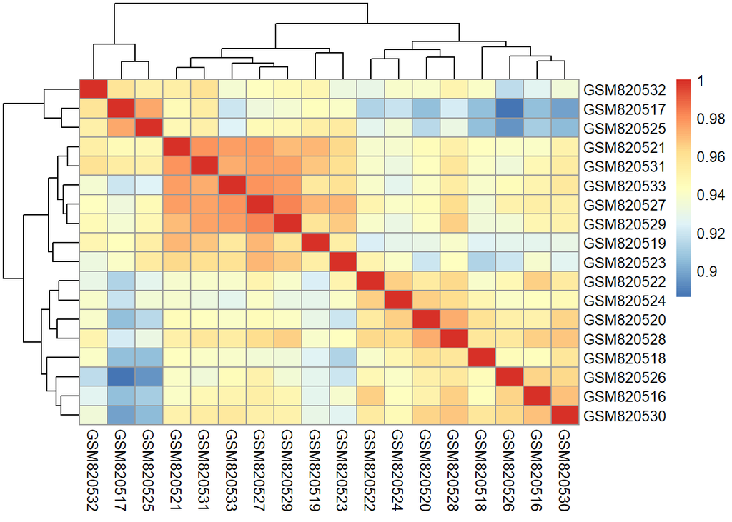

```r
library(pheatmap)
## argument use="c" stops an error if there are any missing data points

corMatrix <- cor(exprs(gse),use="c")
pheatmap(corMatrix)
```

We can incorporate sample information onto the plot to try and understand the clustering. We have already created such a data frame previously (`sampleInfo`). However, we need to take care that the rownames of these data match the columns of the correlation matrix.

```r
## Print the rownames of the sample information and check it matches the correlation matrix
rownames(sampleInfo)
```

```
##  [1] "GSM820516" "GSM820517" "GSM820518" "GSM820519" "GSM820520" "GSM820521"
##  [7] "GSM820522" "GSM820523" "GSM820524" "GSM820525" "GSM820526" "GSM820527"
## [13] "GSM820528" "GSM820529" "GSM820530" "GSM820531" "GSM820532" "GSM820533"
```

```r
colnames(corMatrix)
```

```
##  [1] "GSM820516" "GSM820517" "GSM820518" "GSM820519" "GSM820520" "GSM820521"
##  [7] "GSM820522" "GSM820523" "GSM820524" "GSM820525" "GSM820526" "GSM820527"
## [13] "GSM820528" "GSM820529" "GSM820530" "GSM820531" "GSM820532" "GSM820533"
```

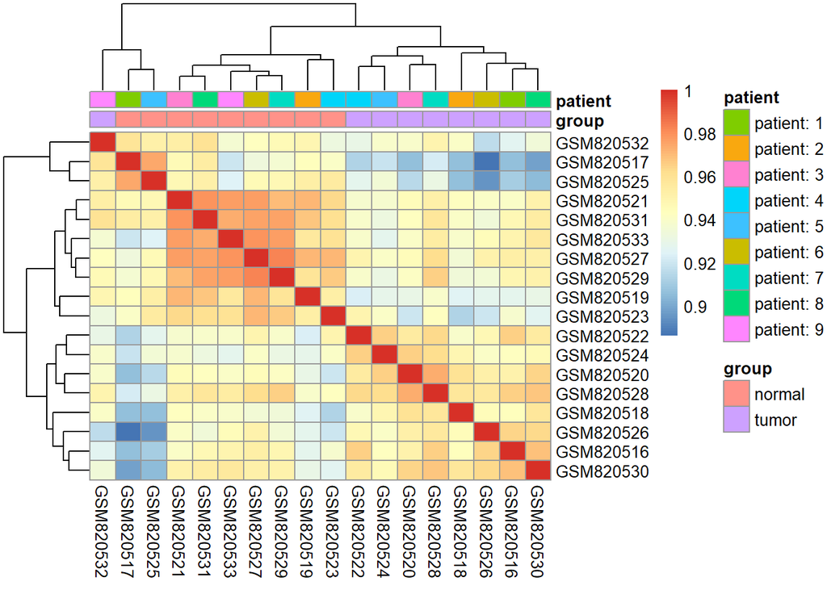

```r
## If not, force the rownames to match the columns

rownames(sampleInfo) <- colnames(corMatrix)
pheatmap(corMatrix,
         annotation_col=sampleInfo)
```

Here we see that the main separation is due to normal vs tumours; as we hope.

A complementary approach is to use Principal Components Analysis (PCA). There is a nice explanation in this youtube video.

https://www.youtube.com/watch?v=0Jp4gsfOLMs

It is important to *transpose* the expression matrix, otherwise R will try and compute PCA on the genes (instead of samples) and quickly run out of memory.

As PCA is an unsupervised method, the known sample groups are not taken into account. However, we can add labels when we plot the results. The `ggplot2` package is particularly convenient for this. The `ggrepel` package can be used to postion the text labels more cleverly so they can be read.

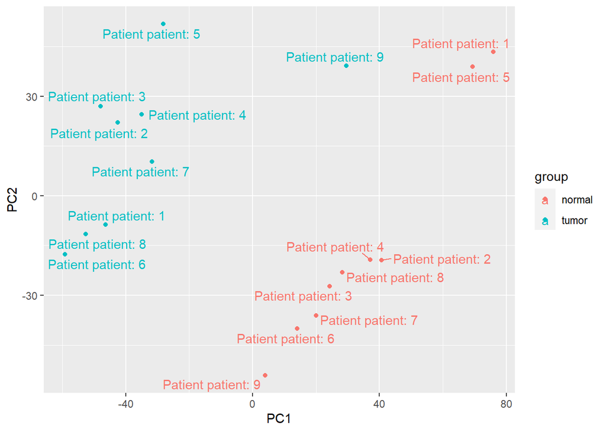

```r
library(ggplot2)
library(ggrepel)
## MAKE SURE TO TRANSPOSE THE EXPRESSION MATRIX

pca <- prcomp(t(exprs(gse)))

## Join the PCs to the sample information
cbind(sampleInfo, pca$x) %>%
ggplot(aes(x = PC1, y=PC2, col=group,label=paste("Patient", patient))) + geom_point() + geom_text_repel()
```

## What happens if we spot a batch effect?

Nothing at this stage. Provided the experimental design is sensible (i.e. representatives from all samples groups are present in each batch) we can correct for batch when we run the differential expression analysis.

## What happens if we detect outliers?

If we suspect some samples are outliers we can remove them for further analysis

```r
### CODE ONLY FOR DEMONSTRATION ONLY

### lets' say are outliers are samples 1,2 and 3
## replace 1,2,3 with the outliers in your dataset
outlier_samples <- c(1,2,3)

gse <- gse[,-outlier_samples]
```

# Exporting the data

We can export the expression data to a `csv` for inspection in Excel using the `write_csv` function from `readr`. The expression values themselves will probably not be very useful as they will be named according to manufacturer ID rather than gene name (for example). We can create a matrix by joining the expression matrix with the feature annotation.

```r
library(readr)
full_output <- cbind(fData(gse),exprs(gse))
write_csv(full_output, path="gse_full_output.csv")
```

The annotation from GEO might contain lots of columns that we are not particularly interested in. To keep the data tidier we can use the `select` function to only print particular columns in the output.

```r
features <- fData(gse)
View(features)
### Look at the features data frame and decide the names of the columns you want to keep
features <- select(features,Symbol,Entrez_Gene_ID,Chromosome,Cytoband)
full_output <- cbind(features,exprs(gse))
write_csv(full_output, path="gse_full_output.csv")
```

# Differential Expression

By far the most-popular package for performing differential expression is `limma`. The user-guide is extensive and covers the theory behind the analysis and many use-cases (Chapters 9 and 17 for single-channel data such as Illumina and Affymetrix)

https://bioconductor.org/packages/release/bioc/vignettes/limma/inst/doc/usersguide.pdf

Crucially, we have to allocate the samples in our dataset to the sample groups of interest. A useful function is `model.matrix`, which will create a *design matrix* from one of the columns in your `sampleInfo`. Here I choose `sampleInfo$group`.

The design matrix is a matrix of `0` and `1`s; one row for each sample and one column for each sample group. A `1` in a particular row and column indicates that a given sample (the row) belongs to a given group (column).

```r
library(limma)
design <- model.matrix(~0+sampleInfo$group)
design
```

```
##    sampleInfo$groupnormal sampleInfo$grouptumor
## 1                       0                     1
## 2                       1                     0
## 3                       0                     1
## 4                       1                     0
## 5                       0                     1
## 6                       1                     0
## 7                       0                     1
## 8                       1                     0
## 9                       0                     1
## 10                      1                     0
## 11                      0                     1
## 12                      1                     0
## 13                      0                     1
## 14                      1                     0
## 15                      0                     1
## 16                      1                     0
## 17                      0                     1
## 18                      1                     0
## attr(,"assign")
## [1] 1 1
## attr(,"contrasts")
## attr(,"contrasts")$`sampleInfo$group`
## [1] "contr.treatment"
```

```r
## the column names are a bit ugly, so we will rename
colnames(design) <- c("Normal","Tumour")
```

The `lmFit` function is used to fit the model to the data. The result of which is to estimate the expression level in each of the groups that we specified.

```r
fit <- lmFit(exprs(gse), design)
head(fit$coefficients)
```

```
##                 Normal    Tumour
## ILMN_1343291 16.087740 16.004200
## ILMN_1343295 14.032346 14.699567
## ILMN_1651199  7.786860  7.763617
## ILMN_1651209  8.079803  8.002217
## ILMN_1651210  7.555458  7.659205
## ILMN_1651221  7.816231  7.801812
```

In order to perform the *differential* analysis, we have to define the contrast that we are interested in. In our case we only have two groups and one contrast of interest. Multiple contrasts can be defined in the `makeContrasts` function.

```r
contrasts <- makeContrasts(Tumour - Normal, levels=design)

## can define multiple contrasts
## e.g. makeContrasts(Group1 - Group2, Group2 - Group3,....levels=design)

fit2 <- contrasts.fit(fit, contrasts)
```

Finally, apply the *empirical Bayes’* step to get our differential expression statistics and p-values.

```r
fit2 <- eBayes(fit2)
```

We usually get our first look at the results by using the `topTable` command

```r
topTable(fit2)
```

```
##                  logFC   AveExpr         t      P.Value    adj.P.Val        B
## ILMN_1704294  3.269052  9.833508  20.85916 4.270310e-14 2.084039e-09 19.87723
## ILMN_1813704  4.749574 10.782232  15.82024 4.927422e-12 1.202365e-07 16.50749
## ILMN_1724686  3.627208 10.814662  15.12049 1.056845e-11 1.719240e-07 15.91540
## ILMN_1811598 -2.380786  9.150986 -13.57845 6.358124e-11 7.757388e-07 14.47449
## ILMN_1659990  1.259224  8.898440  12.63142 2.086244e-10 2.036299e-06 13.48578
## ILMN_1763749 -5.039637 11.894505 -12.24586 3.455391e-10 2.810558e-06 13.05824
## ILMN_1652431 -5.998422 11.580616 -11.74902 6.746951e-10 4.703878e-06 12.48460
## ILMN_1702858 -1.511602  9.233874 -11.54055 8.993340e-10 5.486275e-06 12.23599
## ILMN_1663866  2.038634 14.040020  10.91810 2.173782e-09 1.178746e-05 11.46451
## ILMN_1809456 -1.181448  8.365228 -10.66005 3.169361e-09 1.344462e-05 11.13140
```

The `topTable` function automatically displays the results for the first contrast. If you want to see results for other contrasts

```r
topTable(fit2, coef=1)
```

```
##                  logFC   AveExpr         t      P.Value    adj.P.Val        B
## ILMN_1704294  3.269052  9.833508  20.85916 4.270310e-14 2.084039e-09 19.87723
## ILMN_1813704  4.749574 10.782232  15.82024 4.927422e-12 1.202365e-07 16.50749
## ILMN_1724686  3.627208 10.814662  15.12049 1.056845e-11 1.719240e-07 15.91540
## ILMN_1811598 -2.380786  9.150986 -13.57845 6.358124e-11 7.757388e-07 14.47449
## ILMN_1659990  1.259224  8.898440  12.63142 2.086244e-10 2.036299e-06 13.48578
## ILMN_1763749 -5.039637 11.894505 -12.24586 3.455391e-10 2.810558e-06 13.05824
## ILMN_1652431 -5.998422 11.580616 -11.74902 6.746951e-10 4.703878e-06 12.48460
## ILMN_1702858 -1.511602  9.233874 -11.54055 8.993340e-10 5.486275e-06 12.23599
## ILMN_1663866  2.038634 14.040020  10.91810 2.173782e-09 1.178746e-05 11.46451
## ILMN_1809456 -1.181448  8.365228 -10.66005 3.169361e-09 1.344462e-05 11.13140
```

```r
### to see the results of the second contrast (if it exists)
## topTable(fit2, coef=2)
```

If we want to know how many genes are differentially-expressed overall we can use the `decideTests` function.

```r
decideTests(fit2)
```

```
## TestResults matrix
##               Contrasts
##                Tumour - Normal
##   ILMN_1343291               0
##   ILMN_1343295               0
##   ILMN_1651199               0
##   ILMN_1651209               0
##   ILMN_1651210               0
## 48798 more rows ...
```

```r
table(decideTests(fit2))
```

```
##
##    -1     0     1
##  1097 46219  1487
```

# Further processing and visualisation of DE results

At the moment our results are not particularly easy to navigate as the only information to identify each gene is the identifier that the microarray manufacturer has assigned. Fortunately, the GEO entry contains extensive annotation that we can add. The annotation data can be retrieved with the `fData` function and we restrict to columns we are interested in using `select`.

**For your own data, you will have to choose the columns that are of interest to you. You probably won’t have the same column headings used here**.

Once an annotation data frame has been created, it can be assigned to our results.

```r
anno <- fData(gse)
anno <- select(anno,Symbol,Entrez_Gene_ID,Chromosome,Cytoband)
fit2$genes <- anno
topTable(fit2)
```

```
##                Symbol Entrez_Gene_ID Chromosome       Cytoband     logFC
## ILMN_1704294     CDH3           1001         16       16q22.1c  3.269052
## ILMN_1813704 KIAA1199          57214         15       15q25.1b  4.749574
## ILMN_1724686    CLDN1           9076          3          3q28c  3.627208
## ILMN_1811598    ADH1B            125          4          4q23b -2.380786
## ILMN_1659990     HIG2          29923          7        7q32.1a  1.259224
## ILMN_1763749   GUCA2A           2980          1        1p34.2b -5.039637
## ILMN_1652431      CA1            759          8        8q21.2b -5.998422
## ILMN_1702858   ADHFE1         137872          8        8q13.1b -1.511602
## ILMN_1663866    TGFBI           7045          5 5q31.1f-q31.2a  2.038634
## ILMN_1809456    CNTFR           1271          9        9p13.3c -1.181448
##                AveExpr         t      P.Value    adj.P.Val        B
## ILMN_1704294  9.833508  20.85916 4.270310e-14 2.084039e-09 19.87723
## ILMN_1813704 10.782232  15.82024 4.927422e-12 1.202365e-07 16.50749
## ILMN_1724686 10.814662  15.12049 1.056845e-11 1.719240e-07 15.91540
## ILMN_1811598  9.150986 -13.57845 6.358124e-11 7.757388e-07 14.47449
## ILMN_1659990  8.898440  12.63142 2.086244e-10 2.036299e-06 13.48578
## ILMN_1763749 11.894505 -12.24586 3.455391e-10 2.810558e-06 13.05824
## ILMN_1652431 11.580616 -11.74902 6.746951e-10 4.703878e-06 12.48460
## ILMN_1702858  9.233874 -11.54055 8.993340e-10 5.486275e-06 12.23599
## ILMN_1663866 14.040020  10.91810 2.173782e-09 1.178746e-05 11.46451
## ILMN_1809456  8.365228 -10.66005 3.169361e-09 1.344462e-05 11.13140
```

The “*Volcano Plot*” function is a common way of visualising the results of a DE analysis. The $x$ axis shows the log-fold change and the $y$ axis is some measure of statistical significance, which in this case is the log-odds, or “B” statistic. A characteristic “volcano” shape should be seen.

First we create a data frame that we can visualise in `ggplot2`. Specifying the `number` argument to `topTable` creates a table containing test results from all genes. We also put the probe IDs as a column rather than row names.

```r
full_results <- topTable(fit2, number=Inf)
full_results <- tibble::rownames_to_column(full_results,"ID")
```

The basic plot is created as follows:-

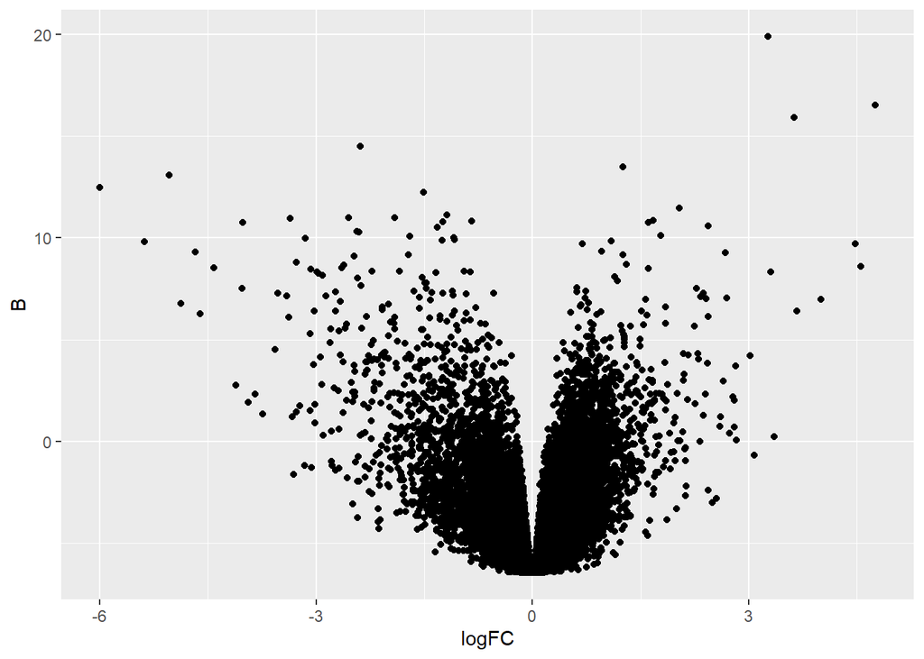

```r
## Make sure you have ggplot2 loaded
library(ggplot2)
ggplot(full_results,aes(x = logFC, y=B)) + geom_point()
```

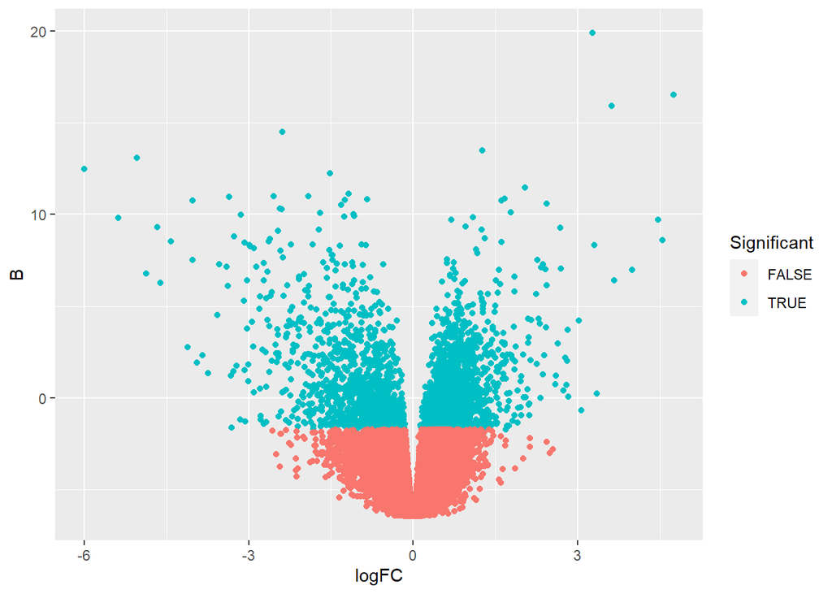

```r
## change according to your needs
p_cutoff <- 0.05
fc_cutoff <- 1

full_results %>%
  mutate(Significant = adj.P.Val < p_cutoff, abs(logFC) > fc_cutoff ) %>%
  ggplot(aes(x = logFC, y = B, col=Significant)) + geom_point()
```

# Filtering and exporting the results table

The `filter` function from `dplyr` gives a convenient way to interrogate the table of results.

```r
## Get the results for particular gene of interest
filter(full_results, Symbol == "SMOX")
```

```
##             ID Symbol Entrez_Gene_ID Chromosome Cytoband     logFC  AveExpr
## 1 ILMN_2367258   SMOX          54498         20   20p13b 1.2539578 8.794859
## 2 ILMN_1775380   SMOX          54498         20   20p13b 1.3072319 9.308779
## 3 ILMN_2280707   SMOX          54498         20   20p13b 0.1496249 7.824136
##          t      P.Value    adj.P.Val         B
## 1 9.244048 2.847762e-08 3.756199e-05  9.154108
## 2 8.931252 4.770362e-08 5.820199e-05  8.681121
## 3 1.592315 1.286518e-01 4.712950e-01 -5.233722
```

```r
## Get results for genes with TP53 in the name
filter(full_results, grepl("TP53", Symbol))
```

```
##              ID   Symbol Entrez_Gene_ID Chromosome      Cytoband        logFC
## 1  ILMN_1686906 TP53INP2          58476         20     20q11.22b -1.199901757
## 2  ILMN_1664440  TP53BP1           7158         15      15q15.3a  0.362603673
## 3  ILMN_1764851   TP53RK         112858         20     20q13.12c  0.414860251
## 4  ILMN_2358919   TP53I3           9540          2       2p23.3d -0.503277167
## 5  ILMN_2159152  TP53TG3          24150         16      16p11.2b -0.182837065
## 6  ILMN_1779356     TP53           7157         17      17p13.1d  0.423518041
## 7  ILMN_2270299  TP53BP2           7159          1 1q41e-q42.11a  0.147061657
## 8  ILMN_2412624  TP53I11           9537         11      11p11.2d  0.151814913
## 9  ILMN_1699389  TP53TG3          24150         16      16p11.2b  0.110761513
## 10 ILMN_1663932  TP53TG3          24150         16      16p11.2b -0.040138231
## 11 ILMN_1658469  TP53AP1          11257          7               -0.165945830
## 12 ILMN_1715669  TP53I11           9537         11      11p11.2d  0.135454738
## 13 ILMN_2214197 TP53INP1          94241          8       8q22.1c -0.153266899
## 14 ILMN_1666178  TP53I13          90313         17      17q11.2b -0.098716565
```

[output cut: 21 more lines]

```r
## Get results for one chromosome
filter(full_results, Chromosome==20)
```

```
##               ID         Symbol Entrez_Gene_ID Chromosome          Cytoband
## 1   ILMN_2367258           SMOX          54498         20            20p13b
## 2   ILMN_1775380           SMOX          54498         20            20p13b
## 3   ILMN_2358886           EDN3           1908         20         20q13.32b
## 4   ILMN_1753449           CST1           1469         20         20p11.21b
## 5   ILMN_1703205           EDN3           1908         20         20q13.32b
## 6   ILMN_1695687          SALL4          57167         20          20q13.2a
## 7   ILMN_1787815          TRIB3          57761         20            20p13f
## 8   ILMN_1731948           PCK1           5105         20         20q13.31a
## 9   ILMN_1686906       TP53INP2          58476         20         20q11.22b
## 10  ILMN_1727200        SLCO4A1          28231         20         20q13.33d
## 11  ILMN_1662640      C20orf127         140851         20         20q11.22b
## 12  ILMN_1721128         TOMM34          10953         20         20q13.12b
## 13  ILMN_2108735         EEF1A2           1917         20         20q13.33e
## 14  ILMN_1714197          ACSS2          55902         20         20q11.22b
```

[output cut: 1757 more lines]

We can also filter according to p-value (adjusted) and fold-change cut-offs

```r
p_cutoff <- 0.05
fc_cutoff <- 1

filter(full_results, adj.P.Val < 0.05, abs(logFC) > 1)
```

```
##               ID     Symbol Entrez_Gene_ID    Chromosome          Cytoband
## 1   ILMN_1704294       CDH3           1001            16          16q22.1c
## 2   ILMN_1813704   KIAA1199          57214            15          15q25.1b
## 3   ILMN_1724686      CLDN1           9076             3             3q28c
## 4   ILMN_1811598      ADH1B            125             4             4q23b
## 5   ILMN_1659990       HIG2          29923             7           7q32.1a
## 6   ILMN_1763749     GUCA2A           2980             1           1p34.2b
## 7   ILMN_1652431        CA1            759             8           8q21.2b
## 8   ILMN_1702858     ADHFE1         137872             8           8q13.1b
## 9   ILMN_1663866      TGFBI           7045             5    5q31.1f-q31.2a
## 10  ILMN_1809456      CNTFR           1271             9           9p13.3c
## 11  ILMN_1709399   SLC25A34         284723             1          1p36.21a
## 12  ILMN_1743445    FAM107A          11170             3           3p14.2d
## 13  ILMN_1657435       MT1M           4499            16            16q13b
## 14  ILMN_1772521    MTHFD1L          25902             6    6q25.1b-q25.1c
```

[output cut: 1643 more lines]

These results can be exported with the `write_csv` function.

```r
library(readr)
filter(full_results, adj.P.Val < 0.05, abs(logFC) > 1) %>%
  write_csv(path="filtered_de_results.csv")
```